# CTT Radio Tag User Guide

support@celltracktech.com

11/15/2023

# 1 Introduction

Currently CTT offers digitally-coded radio tags in two frequencies and several formats. The two frequencies are 434MHz (UHF), and 2.4GHz (Bluetooth) In the case of the 434MHz tags, these come in three distinct flavors:

## 1.1 434MHz Radio Tags

1. **LifeTag** - a solar-only tag, this tag is great for diurnally-active species that need the lightest weight available. LifeTags can be as light as 0.35g, and go up from there depending on your species and needs. The most bare-bones tag, plus a flexible tab for harnessing, light nitinol antenna, and enough epoxy coating to protect it from the elements will come in between 0.45 and 0.6g depending on the amount of epoxy. Because of their battery-less design, the LifeTag can last for many seasons and years with proper attachment. LifeTag is programmed with a standard 5-second beep rate.
2. **PowerTag** - PowerTag is the *yin* to the LifeTag’s *yang*; a battery-only radio tag with a user-defined beep rate, allowing the user to balance tag longevity and the desired tag weight. this tag is great for the smallest species, those that are only active at night, or those that spend most of their lives under dense cover.
3. **HybridTag** - The Hybrid Tag represents the cosmic duality of both the LifeTag, and PowerTag, and is therefore the go-to tag for most species. Combining the breakthrough technology of the LifeTag with the benefits of a rechargeable battery results in a very light tag (0.65g with light epoxy coating, flexible attachment tab, and light antenna) that can beep 24-hours a day, last multiple seasons and years, and only requires several hours of sunlight over the course of three days to remain fully charged.

## 1.2 2.4GHz Radio Tags

1. **BlūMorpho** - The BlūMorpho brings solar-powered tagging to the tiniest of animals, with a tag weighing about that of a grain of rice (0.06g) and measuring less than 4cm, with antenna included. This tag is appropriate for a number of species ranging from Monarch butterflies and bumble bees, to all hummingbirds, and many more.

## 1.3 Using This Guide

Use the `Quick Start Guide` in the next section to get you up and running with your `Digitally-coded Radio Tags`. If you run into any complications, please get in touch with us via our `Customer Service Desk` portal [here](https://celltracktech.com/pages/customer-service-desk-csd).

For preparing to deploy any of these tag types, you will need a way to detect the tag. We recommend either a `CTT Sidekick`, or an operational `SensorStation` and a way to connect to it, either via ethernet or WiFi adapter.

# 2 434MHz Radio Tag Quickstart Guides

## 2.1 LifeTag Quickstart Guide

Because there is no battery, deploying a LifeTag is very simple.

1. Unpack your LifeTag. Note that your LifeTag ships with an 8-digit digital ID sticker.
2. Record the unique digital IDs for each of your tags.
3. Place your `LifeTag`, solar panel facing up, in a location where it can get some direct light and within detection range of your `SensorStation` (*note: if not using antennas on your SensorStation, make sure tags are within a meter of the station*) or `CTT Locator`.
4. If using the locator, power-up and connect your Locator to a smart device following the directions in the Locator User Guide [here] (https://cellular-tracking-technologies.github.io/ctt_documentation/CTT_locator_user_guide.html).
5. Connect your computer to your SensorStation so you can view the web interface (*for SensorStation operation consult the online install guide [here](https://cellular-tracking-technologies.github.io/ctt_documentation/v2-SensorStation-User-Guide.html#connecting-to-your-sensorstation-web-interface)*).
6. Ensure your SensorStation has at least one radio tuned to detect `Tags` (*if this isn’t clear, consult the SensorStation online install guide*).
7. You should now see the digital ID of the tag showing up in either the Locator interface on your smart device, or on the radio channels (1 through 5) on the SensorStation Interface on your computer.

## 2.2 PowerTag Quickstart Guide

PowerTags are a little different in that they operate solely on battery, and therefore need a more precise way to activate and deactivate them. The CTT Activator can be used to do both.

1. Unpack your PowerTag. Note that your PowerTag ships with an 8-digit digital ID sticker.
2. Record the unique digital IDs for each of your tags.
3. Follow the directions printed on the CTT Activator to activate your PowerTag.
4. Confirm activation on the Activator by seeing the red beep indicator light flashing at the expected beep rate (the beep rate you selected when placing your order).
5. If your tag fails to activate at first, try activating in different orientations. The transmitter board is on either side of the tag depending on build, so there are cases when the battery or a thick epoxy may preclude activation from a single orientation; flipping the tag and trying again will usually fix it. All tags are activated and de-activated at the office prior to shipping so there’s definitely a correct orientation!

*Note on the Activator*: *If you have issues with your activator, the most common problem is the internal activator battery is too low and need to be recharged. Two options are to either fully charge the battery by plugging in the Activator, or using the Activator while it is plugged into AC power.*

6. It is always best practice to confirm tag detection on either a CTT Locator or a CTT SensorStation. See steps 4-7 under LifeTag QuickStart above.

## 2.3 HybridTag Quickstart Guide

Like the LifeTag, the HybridTag will beep when sun is hitting the panel, but will switch to battery power when there is no light. The HybridTag comes with a small magnet taped to the back of the tag. The magnet keeps the tag from using the battery to transmit its digital signal. By removing the magnet you will activate the battery and, assuming the battery is charged, you should experience immediate beeping.

1. Unpack your HybridTag. Note that your HybridTag ships with an 8-digit digital ID sticker.
2. Record the unique digital IDs for each of your tags.
3. Remove the tape and magnet from the back of your HybridTag and store it for turning off a HybridTag in the future (such as when you’re done with this test!)
4. If using the locator, power-up and connect your Locator to a smart device following the directions in the Locator User Guide [here] (https://cellular-tracking-technologies.github.io/ctt_documentation/CTT_locator_user_guide.html).
5. Connect your computer to your SensorStation so you can view the web interface (*for SensorStation operation consult the online install guide [here](https://cellular-tracking-technologies.github.io/ctt_documentation/v2-SensorStation-User-Guide.html#connecting-to-your-sensorstation-web-interface)*).
6. Ensure your SensorStation has at least one radio tuned to detect `Tags` (*if this isn’t clear, consult the SensorStation online install guide*).
7. You should now see the digital ID of the tag showing up in either the Locator interface on your smart device, or on the radio channels (1 through 5) on the SensorStation Interface on your computer.
8. If the tag fails to beep, and is not in the sun, go ahead and place it in direct sun and see if it then starts to function. If this happens it means that the battery is flat and needs to recharge. Place the magnet back on the tag and place the tag in the sun for several hours to fully recharge. Then repeat the test again, covering the solar panel to ensure that your tag is beeping using battery power.

# 3 2.4GHz Radio Tag Quickstart Guides

## 3.1 BlūMorpho Quick Start Guide

Congratulations on receiving your new BlūMorpho 2.4GHz Transmitters! Because these tags are so tiny and light, we had to do a few things to ensure their secure delivery to you, and hopefully help you manage them once in your possession. Please read below and familiarize yourself with the layout of your tag package prior to any cutting or deploying.

Upon opening your Tri-fold envelope, you’ll see your tags suspended behind a retention strip (Fig 1). You will also find some useful information printed at the bottom of the envelope, including your order #, the reference number printed on the panel to which your tags are attached, and the Tag ID, which is the ID you will see when detecting your tag with a receiver.

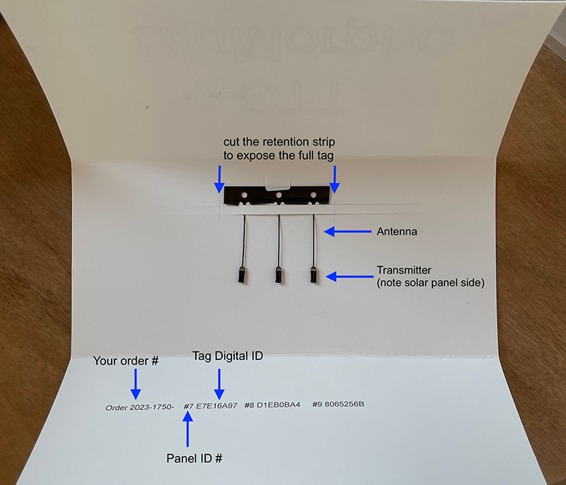

*Fig 1. The tri-fold envelope holding your BlūMorpho tags. Note the retention strip holding the antennas down, and the small white sticker holding the panel strip to the envelope.*

- **Note the tags are solar-panel up (also depicted in Fig 2) which is the way you will want to deploy them on an animal.**

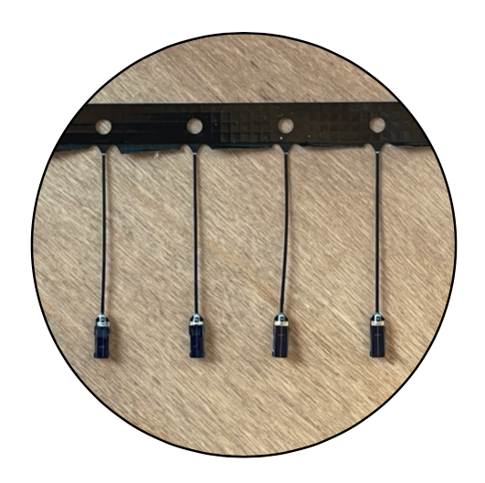

*Fig 2. The upperside of the BlūMorpho transmitter showing the solar panel as well as the small cutline indicating where you should cut to separate the tag and antenna from the panel strip. This cut line results in a 1/4 wavelength antenna.*

- In Fig 2, also notice that there is a small white “cut line” at the top of the antenna, where it meets the panel strip. This is the ONLY place where you should cut your tag to remove it from the panel strip and deploy it on an animal.

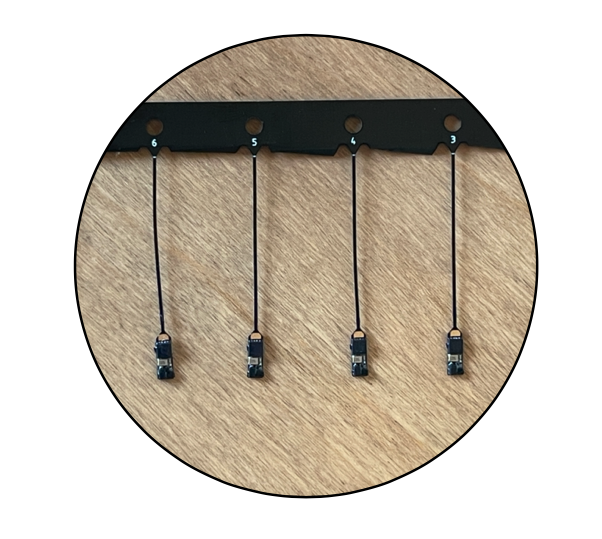

*Fig 3. The underside of the BlūMorpho tag showing the reference “Panel ID numbers” along the top of the Panel*

- In Fig 3 you’ll see the same tags, but from the component side (the underside of the tag). Here you can see the Panel ID numbers on the panel strip. These numbers are your reference to the full Tag Digital ID # that will show up on your receiver. Make sure you note these for your records, as the tag’s ID is NOT printed on the tag itself.

# 4 Final Thoughts

This User Guide is a living document. Your experiences and input are greatly appreciated so please don’t hesitate to reach out to us regarding what you’d like to see included here. You can submit your suggestions and any errors to our `Customer Service Desk` [here](https://celltracktech.com/pages/customer-service-desk-csd) and we will work to incorporate them in future revisions. All material © Cellular Tracking Technologies, 2023.